# W_AIML_ML_Project_Personal_Loan (1)

Personal Loan Purchase Prediction

## Problem Statement

### Context

AllLife Bank is a US bank that has a growing customer base. The majority of these customers are liability customers (depositors) with varying sizes of deposits. The number of customers who are also borrowers (asset customers) is quite small, and the bank is interested in expanding this base rapidly to bring in more loan business and in the process, earn more through the interest on loans. In particular, the management wants to explore ways of converting its liability customers to personal loan customers (while retaining them as depositors).

A campaign that the bank ran last year for liability customers showed a healthy conversion rate of over 9% success. This has encouraged the retail marketing department to devise campaigns with better target marketing to increase the success ratio.

You as a Data scientist at AllLife bank have to build a model that will help the marketing department to identify the potential customers who have a higher probability of purchasing the loan.

### Objective

To predict whether a liability customer will buy personal loans, to understand which customer attributes are most significant in driving purchases, and identify which segment of customers to target more.

### Data Dictionary

- `ID`: Customer ID
- `Age`: Customer’s age in completed years
- `Experience`: #years of professional experience
- `Income`: Annual income of the customer (in thousand dollars)
- `ZIP Code`: Home Address ZIP code.
- `Family`: the Family size of the customer
- `CCAvg`: Average spending on credit cards per month (in thousand dollars)
- `Education`: Education Level. 1: Undergrad; 2: Graduate;3: Advanced/Professional
- `Mortgage`: Value of house mortgage if any. (in thousand dollars)
- `Personal_Loan`: Did this customer accept the personal loan offered in the last campaign? (0: No, 1: Yes)
- `Securities_Account`: Does the customer have securities account with the bank? (0: No, 1: Yes)
- `CD_Account`: Does the customer have a certificate of deposit (CD) account with the bank? (0: No, 1: Yes)
- `Online`: Do customers use internet banking facilities? (0: No, 1: Yes)
- `CreditCard`: Does the customer use a credit card issued by any other Bank (excluding All life Bank)? (0: No, 1: Yes)

## Importing necessary libraries

```python
# # Libraries to help with reading and manipulating data
import pandas as pd
import numpy as np

# # libaries to help with data visualization
import matplotlib.pyplot as plt
import seaborn as sns

# # Library to split data
from sklearn.model_selection import train_test_split

# # To build model for prediction
from sklearn.tree import DecisionTreeClassifier
from sklearn import tree

# # To get diferent metric scores
from sklearn.metrics import accuracy_score, precision_score, recall_score, f1_score, confusion_matrix, ConfusionMatrixDisplay


# # to suppress unnecessary warnings
import warnings
warnings.filterwarnings("ignore")
```

## Loading the dataset

```python
# load the dataset -Loan Modelling
```

```python
df = pd.read_csv('Loan_Modelling.csv')
```

```python
df.head()
```

|  | ID | Age | Experience | Income | ZIPCode | Family | CCAvg | Education | Mortgage | Personal_Loan | Securities_Account | CD_Account | Online | CreditCard |
| --- | --- | --- | --- | --- | --- | --- | --- | --- | --- | --- | --- | --- | --- | --- |
| 0 | 1 | 25 | 1 | 49 | 91107 | 4 | 1.6 | 1 | 0 | 0 | 1 | 0 | 0 | 0 |
| 1 | 2 | 45 | 19 | 34 | 90089 | 3 | 1.5 | 1 | 0 | 0 | 1 | 0 | 0 | 0 |
| 2 | 3 | 39 | 15 | 11 | 94720 | 1 | 1.0 | 1 | 0 | 0 | 0 | 0 | 0 | 0 |
| 3 | 4 | 35 | 9 | 100 | 94112 | 1 | 2.7 | 2 | 0 | 0 | 0 | 0 | 0 | 0 |
| 4 | 5 | 35 | 8 | 45 | 91330 | 4 | 1.0 | 2 | 0 | 0 | 0 | 0 | 0 | 1 |

```python
df.tail()
```

|  | ID | Age | Experience | Income | ZIPCode | Family | CCAvg | Education | Mortgage | Personal_Loan | Securities_Account | CD_Account | Online | CreditCard |
| --- | --- | --- | --- | --- | --- | --- | --- | --- | --- | --- | --- | --- | --- | --- |
| 4995 | 4996 | 29 | 3 | 40 | 92697 | 1 | 1.9 | 3 | 0 | 0 | 0 | 0 | 1 | 0 |
| 4996 | 4997 | 30 | 4 | 15 | 92037 | 4 | 0.4 | 1 | 85 | 0 | 0 | 0 | 1 | 0 |
| 4997 | 4998 | 63 | 39 | 24 | 93023 | 2 | 0.3 | 3 | 0 | 0 | 0 | 0 | 0 | 0 |
| 4998 | 4999 | 65 | 40 | 49 | 90034 | 3 | 0.5 | 2 | 0 | 0 | 0 | 0 | 1 | 0 |
| 4999 | 5000 | 28 | 4 | 83 | 92612 | 3 | 0.8 | 1 | 0 | 0 | 0 | 0 | 1 | 1 |

## Data Overview

```python
# sanity checks
# df.info()
# check the datatype - numerical - numerical , cat - cat - check the validity
# df.describe() - 5 point summary - detect the anamolies in the data - min and max
# df.head()
# df.tail()
# df.sample(20) - structure of the data - view and see for any anamolies - clean that the anamolies
# df.shape
# df.columns
# df.dtypes
# df.isnull().sum() -
# df.duplicated().sum() - you do this before removing the ID columns
# df.nunique() - levels of each categorical variables - how many sub categories
```

```python
df.info()
```

```
<class 'pandas.core.frame.DataFrame'>
RangeIndex: 5000 entries, 0 to 4999
Data columns (total 14 columns):
 #   Column              Non-Null Count  Dtype
---  ------              --------------  -----
 0   ID                  5000 non-null   int64
 1   Age                 5000 non-null   int64
 2   Experience          5000 non-null   int64
 3   Income              5000 non-null   int64
 4   ZIPCode             5000 non-null   int64
 5   Family              5000 non-null   int64
 6   CCAvg               5000 non-null   float64
 7   Education           5000 non-null   int64
 8   Mortgage            5000 non-null   int64
 9   Personal_Loan       5000 non-null   int64
 10  Securities_Account  5000 non-null   int64
 11  CD_Account          5000 non-null   int64
 12  Online              5000 non-null   int64
 13  CreditCard          5000 non-null   int64
dtypes: float64(1), int64(13)
memory usage: 547.0 KB
```

```python
df.shape
```

```
(5000, 14)
```

> There are 5000 rows and 14 columns

```python
df.columns
```

```
Index(['ID', 'Age', 'Experience', 'Income', 'ZIPCode', 'Family', 'CCAvg',
       'Education', 'Mortgage', 'Personal_Loan', 'Securities_Account',
       'CD_Account', 'Online', 'CreditCard'],
      dtype='object')
```

```python
df.dtypes
```

|  | 0 |
| --- | --- |
| ID | int64 |
| Age | int64 |
| Experience | int64 |
| Income | int64 |
| ZIPCode | int64 |
| Family | int64 |
| CCAvg | float64 |
| Education | int64 |
| Mortgage | int64 |
| Personal_Loan | int64 |
| Securities_Account | int64 |
| CD_Account | int64 |
| Online | int64 |
| CreditCard | int64 |

**dtype:** object

# Data Types:

## All columns are either int64 or float64 → numeric by Pandas, but semantically some are categorical.

# Continuous / Numerical Features :

- Age (int) → continuous, but bounded (valid human age range).
- Experience (int) → continuous, but needs to be consistent with Age.
- Income (int) → continuous, measured in $000s.
- CCAvg (float) → continuous, average monthly spend ($000s).
- Mortgage (int) → continuous, measured in $000s.

# Categorical (though stored as int64) :

- Family → discrete, valid range should be 1-4.
- Education → encoded as 1: Undergrad, 2: Graduate, 3: Professional.
- Securities_Account, CD_Account, Online, CreditCard → binary (0/1).
- Personal_Loan → target variable, binary (0/1).

# Identifiers / Not Predictive :

- ID → unique identifier, should be dropped from modeling.
- ZIPCode → categorical-like, but too granular; usually dropped unless aggregated to regions.

```python
df.describe().T
```

|  | count | mean | std | min | 25% | 50% | 75% | max |
| --- | --- | --- | --- | --- | --- | --- | --- | --- |
| ID | 5000.0 | 2500.500000 | 1443.520003 | 1.0 | 1250.75 | 2500.5 | 3750.25 | 5000.0 |
| Age | 5000.0 | 45.338400 | 11.463166 | 23.0 | 35.00 | 45.0 | 55.00 | 67.0 |
| Experience | 5000.0 | 20.104600 | 11.467954 | -3.0 | 10.00 | 20.0 | 30.00 | 43.0 |
| Income | 5000.0 | 73.774200 | 46.033729 | 8.0 | 39.00 | 64.0 | 98.00 | 224.0 |
| ZIPCode | 5000.0 | 93169.257000 | 1759.455086 | 90005.0 | 91911.00 | 93437.0 | 94608.00 | 96651.0 |
| Family | 5000.0 | 2.396400 | 1.147663 | 1.0 | 1.00 | 2.0 | 3.00 | 4.0 |
| CCAvg | 5000.0 | 1.937938 | 1.747659 | 0.0 | 0.70 | 1.5 | 2.50 | 10.0 |
| Education | 5000.0 | 1.881000 | 0.839869 | 1.0 | 1.00 | 2.0 | 3.00 | 3.0 |
| Mortgage | 5000.0 | 56.498800 | 101.713802 | 0.0 | 0.00 | 0.0 | 101.00 | 635.0 |
| Personal_Loan | 5000.0 | 0.096000 | 0.294621 | 0.0 | 0.00 | 0.0 | 0.00 | 1.0 |
| Securities_Account | 5000.0 | 0.104400 | 0.305809 | 0.0 | 0.00 | 0.0 | 0.00 | 1.0 |
| CD_Account | 5000.0 | 0.060400 | 0.238250 | 0.0 | 0.00 | 0.0 | 0.00 | 1.0 |
| Online | 5000.0 | 0.596800 | 0.490589 | 0.0 | 0.00 | 1.0 | 1.00 | 1.0 |
| CreditCard | 5000.0 | 0.294000 | 0.455637 | 0.0 | 0.00 | 0.0 | 1.00 | 1.0 |

# Demographics :

- Customers are mostly middle-aged: Age ranges 23-67, median ~45 years.
- Experience averages ~20 years, but min is -3 (invalid) → requires correction.

# Financial Profile :

- Income: Wide spread, avg ~73k dollars, median 64k dollars, with high earners up to $224k.
- Mortgage: Highly skewed → half the customers have 0 mortgage, while some go as high as $635k.
- Credit Card Spend (CCAvg): Median ~1.5k dollar/month, but heavy spenders reach 10k dollar .

# Family & Education :

- Family size ranges 1-4, average ~2.4.
- Education: Balanced distribution → Undergrad (1), Graduate (2), Professional (3); all values within valid range.

# Banking Behavior :

- Online banking usage is common (60% use it).
- Credit card ownership (from other banks) is 29%.
- Fewer hold Securities (10%) or CD accounts (6%), indicating cross-sell opportunities.

# Target Variable (Personal Loan) :

- Only 9.6% customers accepted loans → confirms class imbalance.

```python
df.sample(20)
```

|  | ID | Age | Experience | Income | ZIPCode | Family | CCAvg | Education | Mortgage | Personal_Loan | Securities_Account | CD_Account | Online | CreditCard |
| --- | --- | --- | --- | --- | --- | --- | --- | --- | --- | --- | --- | --- | --- | --- |
| 4545 | 4546 | 61 | 35 | 35 | 90025 | 2 | 0.2 | 3 | 0 | 0 | 0 | 0 | 1 | 0 |
| 2124 | 2125 | 35 | 9 | 44 | 92054 | 3 | 0.9 | 1 | 89 | 0 | 0 | 0 | 0 | 0 |
| 3825 | 3826 | 30 | 6 | 69 | 94305 | 4 | 3.4 | 1 | 188 | 0 | 0 | 0 | 0 | 1 |
| 2823 | 2824 | 33 | 7 | 21 | 90095 | 1 | 0.6 | 3 | 0 | 0 | 1 | 0 | 0 | 0 |
| 174 | 175 | 42 | 17 | 168 | 95503 | 2 | 7.9 | 2 | 0 | 1 | 0 | 0 | 1 | 0 |
| 424 | 425 | 56 | 30 | 38 | 92029 | 1 | 0.2 | 1 | 0 | 0 | 0 | 0 | 0 | 0 |
| 548 | 549 | 49 | 23 | 61 | 94117 | 1 | 1.4 | 3 | 0 | 0 | 0 | 0 | 1 | 1 |
| 282 | 283 | 34 | 9 | 71 | 91711 | 4 | 0.7 | 3 | 0 | 0 | 0 | 0 | 1 | 0 |
| 1952 | 1953 | 30 | 5 | 78 | 92037 | 1 | 2.6 | 2 | 0 | 0 | 0 | 0 | 1 | 0 |
| 3955 | 3956 | 62 | 36 | 58 | 94501 | 1 | 0.8 | 2 | 0 | 0 | 0 | 0 | 0 | 0 |
| 1126 | 1127 | 32 | 8 | 104 | 95192 | 2 | 3.7 | 1 | 0 | 1 | 0 | 0 | 0 | 1 |
| 2259 | 2260 | 24 | 0 | 82 | 90401 | 3 | 0.8 | 1 | 0 | 0 | 0 | 0 | 1 | 0 |
| 15 | 16 | 60 | 30 | 22 | 95054 | 1 | 1.5 | 3 | 0 | 0 | 0 | 0 | 1 | 1 |
| 1961 | 1962 | 52 | 26 | 114 | 94304 | 1 | 4.9 | 1 | 0 | 0 | 0 | 0 | 0 | 0 |
| 122 | 123 | 58 | 32 | 73 | 94523 | 2 | 0.7 | 2 | 0 | 0 | 0 | 0 | 1 | 1 |
| 2652 | 2653 | 24 | 0 | 44 | 90089 | 4 | 1.6 | 1 | 180 | 0 | 0 | 0 | 1 | 0 |
| 790 | 791 | 55 | 30 | 58 | 92028 | 4 | 0.9 | 1 | 0 | 0 | 0 | 0 | 1 | 1 |
| 4527 | 4528 | 41 | 16 | 18 | 90024 | 1 | 0.6 | 3 | 0 | 0 | 0 | 0 | 0 | 1 |
| 2104 | 2105 | 40 | 14 | 58 | 90245 | 4 | 0.2 | 3 | 0 | 0 | 0 | 0 | 1 | 0 |
| 4829 | 4830 | 31 | 7 | 11 | 94304 | 1 | 0.5 | 3 | 80 | 0 | 0 | 0 | 1 | 1 |

> **Structure of the Data :** The dataset is structured, numeric, no missing values in this view.

```python
df.isnull().sum()
```

|  | 0 |
| --- | --- |
| ID | 0 |
| Age | 0 |
| Experience | 0 |
| Income | 0 |
| ZIPCode | 0 |
| Family | 0 |
| CCAvg | 0 |
| Education | 0 |
| Mortgage | 0 |
| Personal_Loan | 0 |
| Securities_Account | 0 |
| CD_Account | 0 |
| Online | 0 |
| CreditCard | 0 |

**dtype:** int64

> I observed that there are no null values present in every column

**Drop the columns after checking the duplicates**

```python
# drop the ID Columns
# df.isnull().sum() -
# df.duplicated().sum() - you do this before removing the ID columns
# df.nunique() - levels of each categorical variables - how many sub categories
```

```python
df.duplicated().sum()
```

```
np.int64(0)
```

> There is no duplicated values present the data frame

```python
# Droping the ID columns
df.drop(['ID'], axis=1, inplace=True)
display(df.head())
```

|  | Age | Experience | Income | ZIPCode | Family | CCAvg | Education | Mortgage | Personal_Loan | Securities_Account | CD_Account | Online | CreditCard |
| --- | --- | --- | --- | --- | --- | --- | --- | --- | --- | --- | --- | --- | --- |
| 0 | 25 | 1 | 49 | 91107 | 4 | 1.6 | 1 | 0 | 0 | 1 | 0 | 0 | 0 |
| 1 | 45 | 19 | 34 | 90089 | 3 | 1.5 | 1 | 0 | 0 | 1 | 0 | 0 | 0 |
| 2 | 39 | 15 | 11 | 94720 | 1 | 1.0 | 1 | 0 | 0 | 0 | 0 | 0 | 0 |
| 3 | 35 | 9 | 100 | 94112 | 1 | 2.7 | 2 | 0 | 0 | 0 | 0 | 0 | 0 |
| 4 | 35 | 8 | 45 | 91330 | 4 | 1.0 | 2 | 0 | 0 | 0 | 0 | 0 | 1 |

```python
df.nunique()
```

|  | 0 |
| --- | --- |
| Age | 45 |
| Experience | 47 |
| Income | 162 |
| ZIPCode | 467 |
| Family | 4 |
| CCAvg | 108 |
| Education | 3 |
| Mortgage | 347 |
| Personal_Loan | 2 |
| Securities_Account | 2 |
| CD_Account | 2 |
| Online | 2 |
| CreditCard | 2 |

**dtype:** int64

> 1. Low-cardinality (Categorical / Binary)

> > *Personal_Loan, Securities_Account, CD_Account, Online, CreditCard → only 2 unique values each (0/1).
> > - Education → 3 unique values (Undergrad, Graduate, Professional).
> > - Family → 4 unique values (1-4).
> 1. Medium-cardinality (Discrete Numeric)
> > - Age has 45 distinct values (range ~23-67).
> > - Experience has 47 distinct values (but includes invalid negatives).
> 1. High-cardinality (Continuous Numeric)
> > - Income has 162 distinct values (8-224k).
> > - CCAvg has 108 distinct values (0-10k/month).
> > - Mortgage has 347 distinct values (0-635k).
> > - Clearly continuous with wide spread and skewness.
> 1. Very High-cardinality Identifiers
> > - ZIPCode has 467 unique values.

## Data Preprocessing

```python
# experience columns - negative values (incorrect) but there is may be incorrect at max levels
# remove the -ve and make it positive

# Education levels - make it levels  1-undergrad, 2 -Grads 3 - PostGrad - univariate and bivariate analysis and then later convert into 1,2,3 - encode

# Zip Codes - check whether it is of US - Explore the package which associates the zipcode with the state and region

# cat cols - check - Education, PL, SA,CD,OL,CC,ZIPCODE - By default this will be in int - category/object df['Education].astype(object)
```

```python
# experience columns - negative values (incorrect) but there is may be incorrect at max levels
# remove the -ve and make it positive
df['Experience'] = df['Experience'].apply(lambda x: abs(x) if x < 0 else x)
df["Experience"].describe()
```

|  | Experience |
| --- | --- |
| count | 5000.000000 |
| mean | 20.134600 |
| std | 11.415189 |
| min | 0.000000 |
| 25% | 10.000000 |
| 50% | 20.000000 |
| 75% | 30.000000 |
| max | 43.000000 |

**dtype:** float64

```python
# Map education levels to labels
edu_map = {1: "Undergrad", 2: "Graduate", 3: "PostGrad"}
df["Education_Level"] = df["Education"].map(edu_map)
```

# Instead of numeric (1,2,3), use labels:

> 1 → Undergrad

> 2 → Graduate

> 3 → Postgraduate (Advanced/Professional)

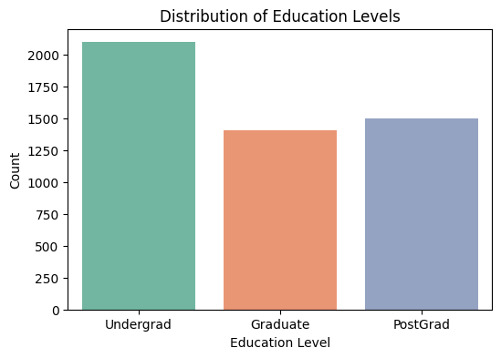

```
Education_Level
Undergrad    2096
PostGrad     1501
Graduate     1403
Name: count, dtype: int64
```

```python
edu_counts = df["Education_Level"].value_counts()
plt.figure(figsize=(6,4))
sns.countplot(x="Education_Level", data=df, order=["Undergrad", "Graduate", "PostGrad"], palette="Set2")
plt.title("Distribution of Education Levels")
plt.xlabel("Education Level")
plt.ylabel("Count")
plt.show()

print(edu_counts)
```

> 1. Undergraduate (1):

> > 2096 customers fall in this group.

> > This is the largest segment in the dataset.
> 1. Graduate (2):

> > 1403 customers are graduates.

> > This is the smallest group among the three.
> 1. Advanced/Professional (3):

> > 1501 customers belong to this category.

> > Slightly higher than graduates but lower than undergraduates.

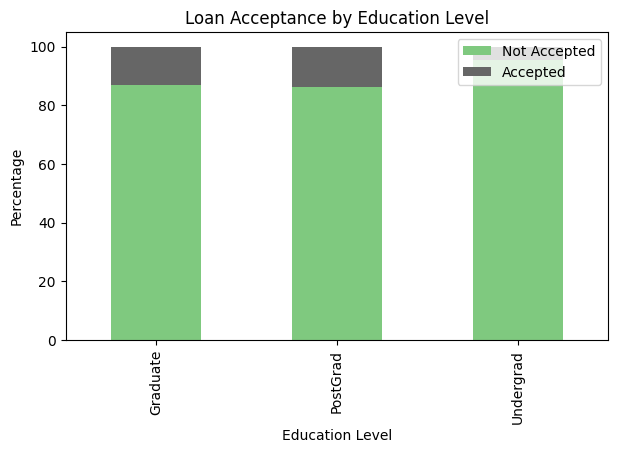

```
Personal_Loan            0          1
Education_Level
Graduate         87.027798  12.972202
PostGrad         86.342438  13.657562
Undergrad        95.562977   4.437023
```

```python
# Crosstab
ct = pd.crosstab(df["Education_Level"], df["Personal_Loan"], normalize="index") * 100

# Stacked bar chart
ct.plot(kind="bar", stacked=True, figsize=(7,4), colormap="Accent")
plt.title("Loan Acceptance by Education Level")
plt.ylabel("Percentage")
plt.xlabel("Education Level")
plt.legend(["Not Accepted", "Accepted"], loc="upper right")
plt.show()

print(ct)
```

> 1. Undergraduates (1)

> > 2003 did not accept loans, 93 accepted.

> > Acceptance rate = 93 / (2003+93) ≈ 4.4% → very low.
> 1. Graduates (2)

> > 1221 did not accept, 182 accepted.

> > Acceptance rate = 182 / (1221+182) ≈ 12.9% → much higher than undergrads.
> 1. Advanced/Professional (3)

> > 1296 did not accept, 205 accepted.

> > Acceptance rate = 205 / (1296+205) ≈ 13.7% → highest acceptance.

> Trend

> > As education level increases, loan acceptance probability also increases.

> > Education seems to have a positive correlation with likelihood of taking a loan.

```python
# Encode back for model
df["Education_Encoded"] = df["Education_Level"].map({"Undergrad":1, "Graduate":2, "PostGrad":3})
```

```python
pip install pgeocode
```

```python
import pgeocode

nomi = pgeocode.Nominatim('us')

# Check random ZIPs from your dataset
print(nomi.query_postal_code("90005"))
print(nomi.query_postal_code("96651"))
```

```
postal_code             90005
country_code               US
place_name        Los Angeles
state_name         California
state_code                 CA
county_name       Los Angeles
county_code              37.0
community_name            NaN
community_code            NaN
latitude              34.0585
longitude           -118.3012
accuracy                  4.0
Name: 0, dtype: object
postal_code       96651
country_code        NaN
place_name          NaN
state_name          NaN
state_code          NaN
county_name         NaN
county_code         NaN
community_name      NaN
community_code      NaN
latitude            NaN
longitude           NaN
accuracy            NaN
Name: 0, dtype: object
```

```python
cat_cols = ["Education", "Personal_Loan", "Securities_Account",
            "CD_Account", "Online", "CreditCard", "ZIPCode"]

for col in cat_cols:
    df[col] = df[col].astype("object")
```

```python
print(df.dtypes[cat_cols])
print(df[cat_cols].nunique())
```

```
Education             object
Personal_Loan         object
Securities_Account    object
CD_Account            object
Online                object
CreditCard            object
ZIPCode               object
dtype: object
Education               3
Personal_Loan           2
Securities_Account      2
CD_Account              2
Online                  2
CreditCard              2
ZIPCode               467
dtype: int64
```

> Education: 3 unique (Undergrad, Graduate, PostGrad)

> Personal_Loan: 2 unique (0,1)

> Securities_Account, CD_Account, Online, CreditCard: 2 unique (0,1)

> ZIPCode: 467 unique

### Univariate Analysis

```python
# Numerical columns
num_col = df.select_dtypes(exclude='object').columns.tolist()

# Categorical columns
cat_col = df.select_dtypes(include='object').columns.tolist()

print("Numerical Columns:", num_col)
print("Categorical Columns:", cat_col)
```

```
Numerical Columns: ['Age', 'Experience', 'Income', 'Family', 'CCAvg', 'Mortgage', 'Education_Encoded']
Categorical Columns: ['ZIPCode', 'Education', 'Personal_Loan', 'Securities_Account', 'CD_Account', 'Online', 'CreditCard', 'Education_Level']
```

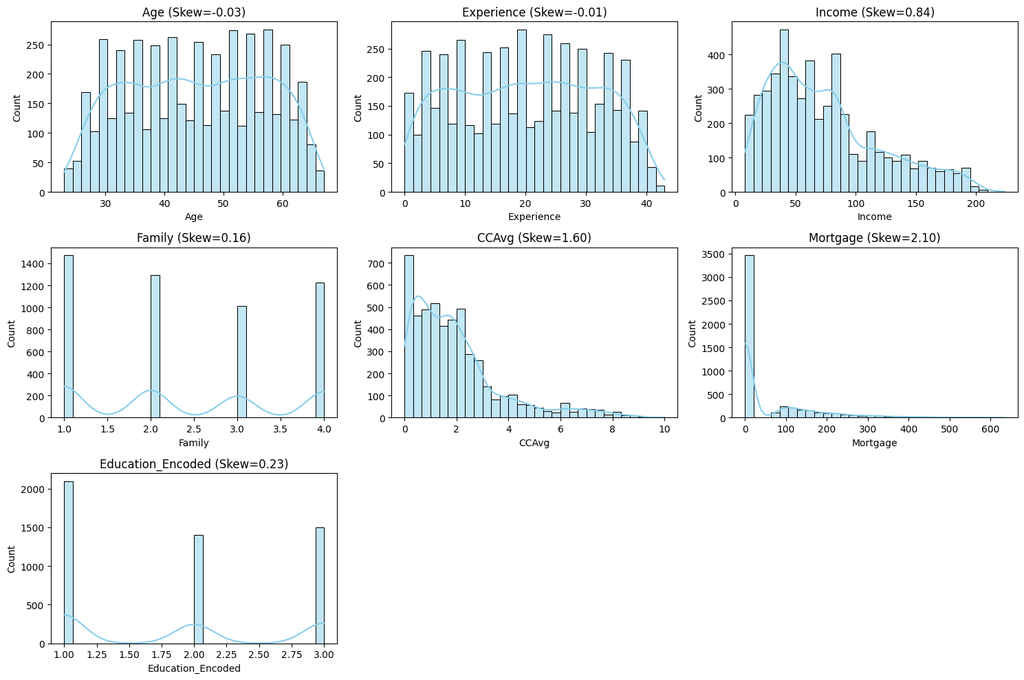

```python
# histogram - analysis - skewness / uniformly  - spread of the data

plt.figure(figsize=(15,10))
for i, col in enumerate(num_col, 1):
    plt.subplot(3, 3, i)
    sns.histplot(df[col], kde=True, bins=30, color="skyblue")
    plt.title(f"{col} (Skew={df[col].skew():.2f})")
plt.tight_layout()
plt.show()
```

> 1. Age (-0.03)

> > Also very close to 0 → symmetric distribution.

> > Since we fixed negative values earlier, it aligns well with Age.
> 1. Income (0.84)

> > Moderate positive skew → More customers earn on the lower end, with a long right tail (few very high earners).
> 1. Family (0.16)

> > Close to symmetric, but slightly right-skewed.

> > Since Family size is discrete (1-4), skewness is not a big concern.
> 1. CCAvg (1.60)

> > High positive skew → Most customers spend very little on credit cards, a few spend heavily.
> 1. Mortgage (2.10)

> > Strong positive skew → Majority have no mortgage (0), a few have very high values.
> > 1. Education_Encoded (0.23)

> > Slightly skewed but almost balanced across 3 levels.

> > Since it is categorical (ordinal), skewness is not as relevant.

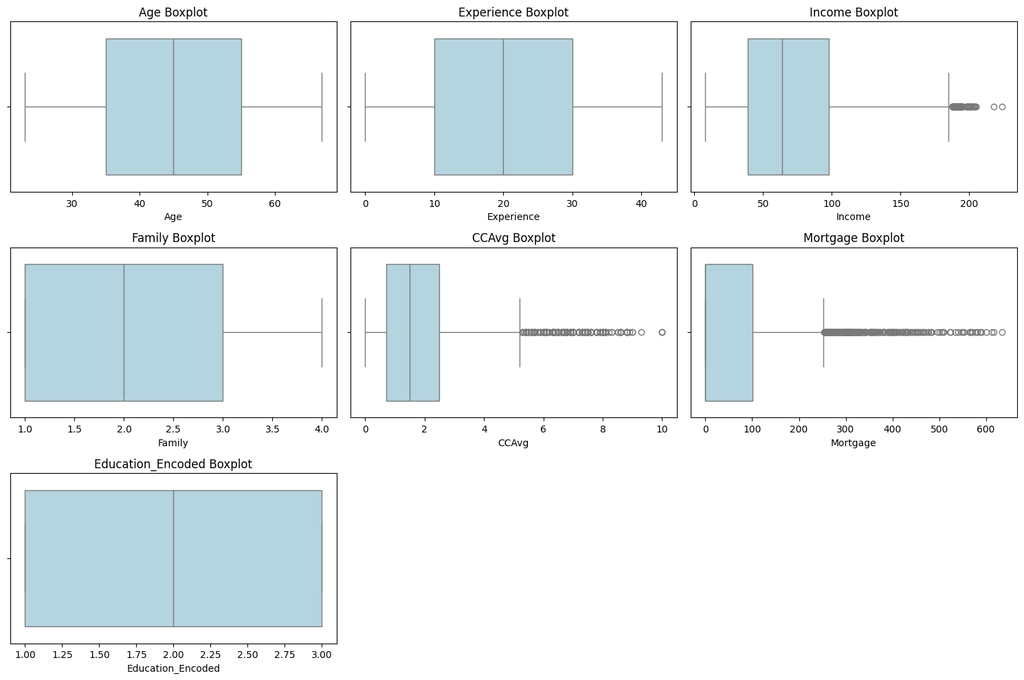

```python
# Boxplots - Identify the outliers
plt.figure(figsize=(15,10))
for i, col in enumerate(num_col, 1):
    plt.subplot(3, 3, i)
    sns.boxplot(x=df[col], color="lightblue")
    plt.title(f"{col} Boxplot")
plt.tight_layout()
plt.show()
```

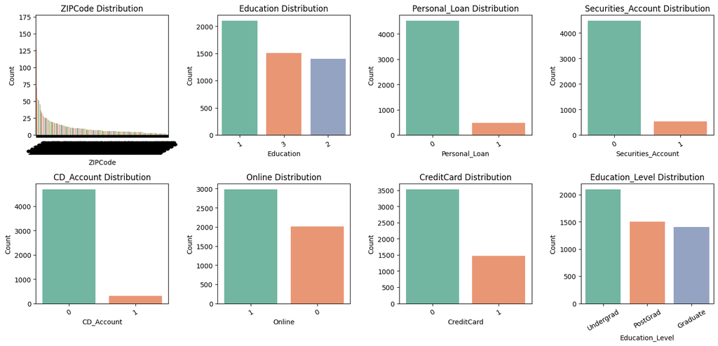

```python
# for categorical variables - countplots - please also write the inferences
plt.figure(figsize=(15,10))

for i, col in enumerate(cat_col, 1):
    plt.subplot(3, 4, i)
    sns.countplot(x=df[col], palette="Set2", order=df[col].value_counts().index)
    plt.title(f"{col} Distribution")
    plt.xlabel(col)
    plt.ylabel("Count")
    plt.xticks(rotation=30)
plt.tight_layout()
plt.show()
```

# Inferences

> 1. Education

> > Undergrad: ~2096

> > Graduate: ~1403

> > PostGrad: ~1501

> > Most customers are Undergraduates, but loan acceptance increases with higher education.
> 1. Personal_Loan (Target)

> > Accepted: 9.6% (~480 customers)

> > Not Accepted: 90.4%

> > Highly imbalanced target variable, so need to handle imbalance (SMOTE/weights).
> 1. Securities_Account

> > Yes: ~10%

> > No: ~90%

> > Very few customers have securities accounts → may not be a strong predictor.
> 1. CD_Account

> > Yes: ~6%

> > No: ~94%

> > Rare category, but in banking datasets CD account holders often have a higher chance of taking loans.
> 1. Online (Internet Banking)

> > Yes: ~60%

> > No: ~40%

> > Majority use online banking → can be correlated with loan behavior.
> 1. CreditCard

> > Yes: ~29%

> > No: ~71%

> > Most customers don't use external credit cards, but credit usage could indicate loan affinity.
> 1. ZIPCode

> > 467 unique categories, each with small counts.

> > Not useful as-is (too many categories). Better to map to State/Region.

### Bivariate Analysis

```python
#Heatmaps - corr() plots
```

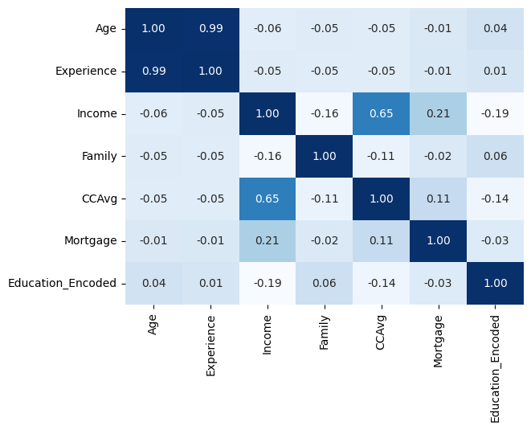

```python
sns.heatmap(
     df[num_col].corr(),
     annot=True,
     cbar=False,
     cmap="Blues",
     fmt=".2f"
 )
```

> 1. Age & Experience (0.99 correlation)

> > Almost perfectly correlated.

> > Suggests redundancy → you can drop one of them (keep only Age or Experience) to avoid multicollinearity.
> 1. Income & CCAvg (0.65 correlation)

> > Strong positive correlation.

> > Makes sense: higher income customers tend to have higher average credit card spending.

> > Both features are useful, but model might assign weight mostly to Income.
> 1. Income & Mortgage (0.21 correlation)

> > Weak positive correlation.

> > Higher income customers are slightly more likely to have mortgages, but not strongly.
> 1. Income & Education (-0.19 correlation)

> > Slight negative correlation with encoded education.

> > Suggests higher education levels don’t always imply higher income in this dataset.
> 1. Family & Income (-0.16 correlation)

> > Small negative relationship: larger families might be associated with slightly lower income (but not strong).

> > Other correlations (close to 0)

> > Most other features are weakly correlated, which is good for machine learning (less redundancy).

```python
#crosstabs - between 2 categorical variables
ct = pd.crosstab(df['Family'], df['Personal_Loan'], margins=True, normalize='index')
print(ct)

# For better visualization with counts
ct_counts = pd.crosstab(df['Family'], df['Personal_Loan'])
print(ct_counts)
```

```
Personal_Loan         0         1
Family
1              0.927310  0.072690
2              0.918210  0.081790
3              0.868317  0.131683
4              0.890344  0.109656
All            0.904000  0.096000
Personal_Loan     0    1
Family
1              1365  107
2              1190  106
3               877  133
4              1088  134
```

> Overall Loan Acceptance:
> > - Across all families, ~9.6% accepted a loan (matches overall dataset).

> Family Size 1 & 2 (Lower Acceptance):
> > - Family = 1 → 7.3% accepted loans (lowest acceptance).
> > - Family = 2 → 8.2% accepted loans.
> > - Smaller families are less likely to opt for personal loans → possibly lower financial burden.

> Family Size 3 (Highest Acceptance):
> > - Family = 3 → 13.2% accepted loans (well above average).
> > - Mid-sized families may have higher expenses (education, lifestyle), increasing loan demand.

> Family Size 4 (Moderately High Acceptance):
> > - Family = 4 → 11% acceptance.
> > - Larger families also tend to borrow more than 1-2 member families, but slightly less than Family = 3.

# Customers with family size 3 or 4 are more likely to accept a personal loan.

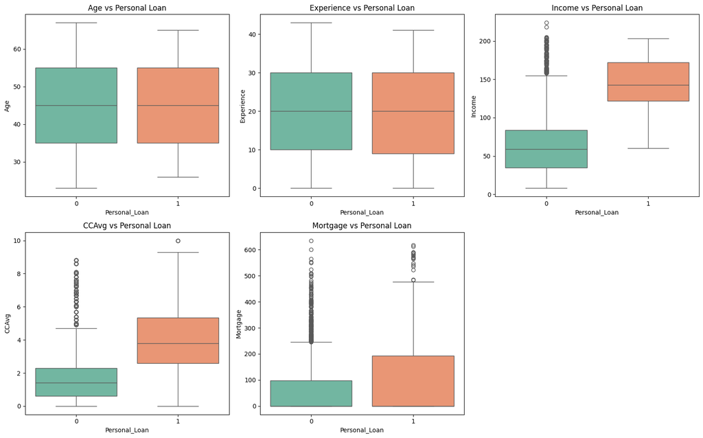

```python
# Bivariate with Boxplots - Independent and Dependent
num_cols = ['Age', 'Experience', 'Income', 'CCAvg', 'Mortgage']

plt.figure(figsize=(16,10))

for i, col in enumerate(num_cols, 1):
    plt.subplot(2, 3, i)
    sns.boxplot(x='Personal_Loan', y=col, data=df, palette="Set2")
    plt.title(f'{col} vs Personal Loan')

plt.tight_layout()
plt.show()
```

> Age vs Personal Loan

> > Distribution looks very similar for loan acceptors and non-acceptors.

> > No clear separation → Age is not a strong predictor.

> Experience vs Personal Loan

> > Similar to Age (high correlation with Age, as seen earlier ~0.99).

> > Both groups show almost identical spread.

> > Not useful alone for predicting loan acceptance.

> Income vs Personal Loan

> > Big difference: Loan acceptors have much higher median income (140k approx) compared to non-acceptors (~60k).

> > Spread is also higher among acceptors.

> > Strong predictor of loan acceptance.

> CCAvg (Credit Card Spend) vs Personal Loan

> > Clear difference: Loan acceptors spend more on credit cards (median 3.5k approx) vs. non-acceptors (~1.5k).

> > Strong separation → very important predictor.

> Mortgage vs Personal Loan

> > Loan acceptors show a slightly higher spread in mortgage amounts.

> > But median is not very different → weak to moderate predictor.

### Multivariate Analysis

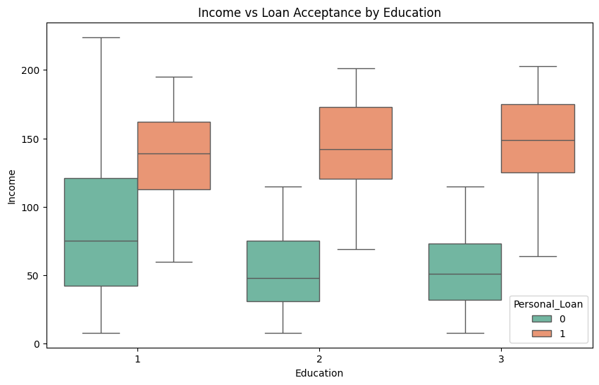

```python
plt.figure(figsize=(10,6))
sns.boxplot(x="Education", y="Income", hue="Personal_Loan", data=df, palette="Set2")
plt.title("Income vs Loan Acceptance by Education")
plt.show()
```

# Trend:

> > Across all education levels, customers who accepted a loan (Personal_Loan = 1) have significantly higher income than those who did not.

> > The effect is strongest for Education = 2 (Graduate) and Education = 3 (Advanced/Professional), where median income is much higher for loan accepters.

> > For Education = 1 (Undergrad), the income difference still exists but with more spread and overlap.

# Insight:

> > Education and Income together strongly influence loan acceptance. Higher education groups with higher income are more likely to accept loans.

> > This suggests that targeting educated and higher-income customers may increase loan acceptance rates.

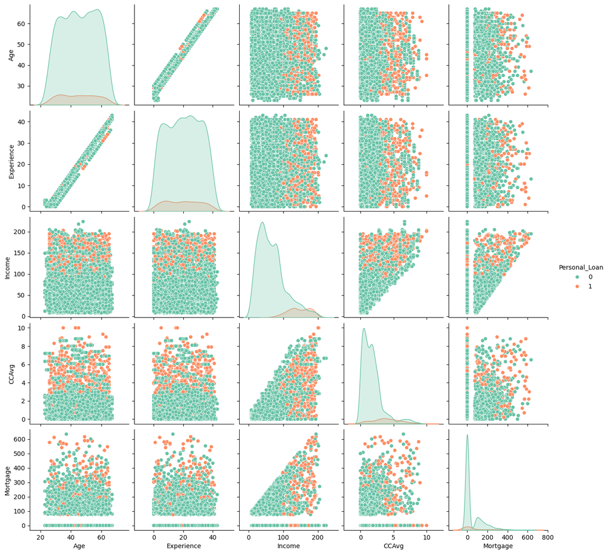

```python
num_cols = ['Age', 'Experience', 'Income', 'CCAvg', 'Mortgage']
sns.pairplot(df[num_cols + ['Personal_Loan']], hue="Personal_Loan", diag_kind="kde", palette="Set2")
plt.show()
```

> Income:

> > Clear separation between those who accepted loans (1) and those who did not (0).

> > Loan accepters tend to have higher income across the scatterplots.

> CCAvg (Credit Card Average Spending):

> > Loan accepters also have higher CCAvg values, suggesting a lifestyle or spending habit linked to borrowing needs.

> Mortgage:

> > Distribution is skewed; many customers have zero mortgage, but those with higher mortgages show a slightly higher loan acceptance.

> Age & Experience:

> > Both are spread out similarly for accepters and non-accepters → not strong differentiators.

> > However, since Age and Experience are almost linearly related (strong diagonal in the pairplot), including both may be redundant for the model.

## Data Preprocessing (contd.)

**Outliers**

```python
# Decision Tree - are not impacted by outliers
# outliers -genuine - they are telling you about some patterns - model - learns
```

### Data Preparation for Modeling

```python
# X = Independent cariables
# y= target variables
# X = pd.get_dummies(X, drop_first=True).astype(float)

# use train_train_split to split the data into train and test - 70: 30
# check the distribution of data into train and test - see how balanced are these data
```

```python
# Independent variables (features)
X = df.drop("Personal_Loan", axis=1)

# Target variable
y = df["Personal_Loan"]
y = y.astype(int)

# Convert categorical variables into dummy/indicator variables
X = pd.get_dummies(X, drop_first=True).astype(float)
```

```python
# Split the data
X_train, X_test, y_train, y_test = train_test_split(
    X, y, test_size=0.3, random_state=42, stratify=y   # stratify ensures balance
)
```

```python
print("Train Distribution:")
print(y_train.value_counts(normalize=True))

print("\nTest Distribution:")
print(y_test.value_counts(normalize=True))
```

```
Train Distribution:
Personal_Loan
0    0.904
1    0.096
Name: proportion, dtype: float64

Test Distribution:
Personal_Loan
0    0.904
1    0.096
Name: proportion, dtype: float64
```

- Train-Test split is well balanced
- Train Set: 90.4% non-loan customers (0), 9.6% loan customers (1)
- Test Set: 90.4% non-loan customers (0), 9.6% loan customers (1)
- This matches exactly with the overall dataset distribution, which means:
- No data leakage or skewing during splitting.
- Both train and test sets are representative of the population.
- The model will learn and be tested on data with the same class proportions, which is important in imbalanced classification problems.

## Model Building

```python
# use the user defined function
# def model_performance_classification_sklearn(model, predictors, target)
# def confusion_matrix_sklearn(model, predictors, target):

# recall, precision and F1 Score
```

### Decision Tree (Basic Model)

```python
model0 = DecisionTreeClassifier(random_state=1)
model0.fit(X_train, y_train)
```

```
DecisionTreeClassifier(random_state=1)
```

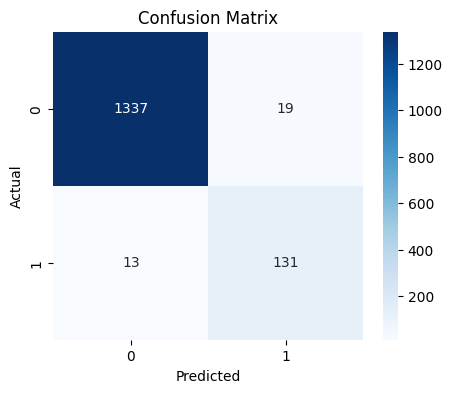

```
=== Test Data Performance ===

=== Train Data Performance (for overfitting check) ===
```

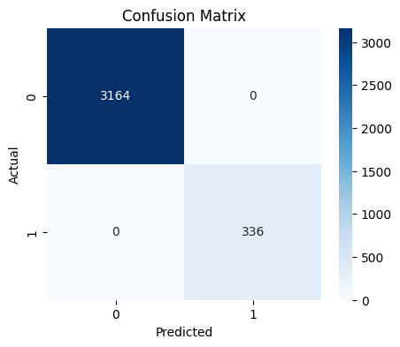

```
=== Test Data Performance ===
```

```python
# confusion_matrix_sklearn
def confusion_matrix_sklearn(model, predictors, target):
    """Plot confusion matrix for classification model"""
    predictions = model.predict(predictors)
    cm = confusion_matrix(target, predictions)

    plt.figure(figsize=(5,4))
    sns.heatmap(cm, annot=True, fmt="d", cmap="Blues",
                xticklabels=[0,1], yticklabels=[0,1])
    plt.xlabel("Predicted")
    plt.ylabel("Actual")
    plt.title("Confusion Matrix")
    plt.show()
    print("=== Test Data Performance ===")
confusion_matrix_sklearn(model0, X_test, y_test)

print("\n=== Train Data Performance (for overfitting check) ===")
confusion_matrix_sklearn(model0, X_train, y_train)
```

> > *True Negatives (TN) = 1337 (class 0 predicted as 0 correctly)

> > *False Positives (FP) = 19 (class 0 misclassified as 1)

> > *False Negatives (FN) = 13 (class 1 misclassified as 0)

> > *True Positives (TP) = 131 (class 1 predicted as 1 correctly)

# Interpretation:

> - Very few misclassifications.

> *Model is balanced (both FP and FN are low).

> From Test Confusion Matrix

> > *True Negatives (TN) = 1337 (class 0 predicted as 0 correctly)

> > *False Positives (FP) = 19 (class 0 misclassified as 1)

> > *False Negatives (FN) = 13 (class 1 misclassified as 0)

> > *True Positives (TP) = 131 (class 1 predicted as 1 correctly)

> Interpretation:

> > *Very few misclassifications.

> > *Model is balanced (both FP and FN are low).

```python
def model_performance_classification_sklearn(model, predictors, target):
    """Return Accuracy, Precision, Recall, and F1 Score as a dictionary"""
    predictions = model.predict(predictors)

    acc = accuracy_score(target, predictions)
    prec = precision_score(target, predictions)
    rec = recall_score(target, predictions)
    f1 = f1_score(target, predictions)

    return {
        "Accuracy": round(acc, 4),
        "Precision": round(prec, 4),
        "Recall": round(rec, 4),
        "F1 Score": round(f1, 4)
    }
print("=== Train Data Performance ===")
decision_tree_default_perf_train = model_performance_classification_sklearn(model0, X_train, y_train)
print(decision_tree_default_perf_train)

print("\n=== Test Data Performance ===")
decision_tree_default_perf_test = model_performance_classification_sklearn(model0, X_test, y_test)
print(decision_tree_default_perf_test)
```

```
=== Train Data Performance ===
{'Accuracy': 1.0, 'Precision': 1.0, 'Recall': 1.0, 'F1 Score': 1.0}

=== Test Data Performance ===
{'Accuracy': 0.9787, 'Precision': 0.8733, 'Recall': 0.9097, 'F1 Score': 0.8912}
```

> Train Data Performance

> > *Accuracy = 1.0

> > *Precision = 1.0

> > *Recall = 1.0

> > *F1 Score = 1.0

> > The model perfectly classified every training sample. This is a clear signal of overfitting because real-world data rarely allows 100% fit unless the model memorized it.

> Train Data Performance

> > *Accuracy = 1.0

> > *Precision = 1.0
> > - Recall = 1.0

> > *F1 Score = 1.0

> > The model perfectly classified every training sample. This is a clear signal of overfitting because real-world data rarely allows 100% fit unless the model memorized it.

```python
model_weighted = DecisionTreeClassifier(random_state=1, class_weight="balanced")
model_weighted.fit(X_train, y_train)

# Evaluate on Train
print("=== Train Data Performance (Weighted) ===")
train_perf_weighted = model_performance_classification_sklearn(
    model_weighted, X_train, y_train
)
print(train_perf_weighted)

# Evaluate on Test
print("\n=== Test Data Performance (Weighted) ===")
test_perf_weighted = model_performance_classification_sklearn(
    model_weighted, X_test, y_test
)
print(test_perf_weighted)
```

```
=== Train Data Performance (Weighted) ===
{'Accuracy': 1.0, 'Precision': 1.0, 'Recall': 1.0, 'F1 Score': 1.0}

=== Test Data Performance (Weighted) ===
{'Accuracy': 0.976, 'Precision': 0.8375, 'Recall': 0.9306, 'F1 Score': 0.8816}
```

# Checking model performance on training data

> Train Data (Weighted)

> > Accuracy = 1.0 → Model still fits the training data perfectly.

> > Precision = 1.0, Recall = 1.0 → No misclassifications in training.

> > This again suggests possible overfitting (too perfect on train).

# Checking model performance on testing data

> Test Data (Weighted)

> > Accuracy = 97.6% → Slightly lower than the default model (97.87%).

> > Precision = 0.8375 → Decreased (default was 0.8733).

> > Recall = 0.9306 → Improved significantly (default was 0.9097).

> > F1 Score = 0.8816 → Slightly lower than default (0.8912).

# Check if the model is in overfit conditions

> > Perfect Training Performance (100%)

> > The tree memorized the training data completely.

> > This is a strong sign of overfitting because real-world data will never be learned perfectly.

> Test Performance Drop

> > Accuracy dropped from 100% → ~97-98% on test.

> > Precision/Recall also dropped on test.

> > This confirms the tree doesn't generalize as well as it memorizes.

> Variance Gap

> > Difference between train and test accuracy = ~2-3% gap.

> > Not extremely large, but combined with perfect train accuracy → indicates overfitting.

#### Visualizing the Decision Tree

[figure not shown]

```python
plt.figure(figsize=(20,10))
tree.plot_tree(
    model0,
    feature_names=X_train.columns,
    class_names=["No Loan", "Loan"],
    filled=True,
    rounded=True,
    fontsize=10
)
plt.show()
```

## Model Performance Improvement

#### Pre-pruning

```python
# --- Function to calculate performance ---
def model_performance_classification_sklearn(model, predictors, target):
    predictions = model.predict(predictors)
    performance = {
        "Accuracy": accuracy_score(target, predictions),
        "Precision": precision_score(target, predictions),
        "Recall": recall_score(target, predictions),
        "F1 Score": f1_score(target, predictions),
    }
    return performance


model1 = DecisionTreeClassifier(
    random_state=1,
    max_depth=5,          # restrict tree depth
    min_samples_leaf=50   # minimum samples per leaf
)

# Train the model
model1.fit(X_train, y_train)

# Train set performance
print("=== Train Data Performance (Pre-pruned) ===")
decision_tree_pruned_perf_train = model_performance_classification_sklearn(
    model1, X_train, y_train
)
print(decision_tree_pruned_perf_train)

# Test set performance
print("\n=== Test Data Performance (Pre-pruned) ===")
decision_tree_pruned_perf_test = model_performance_classification_sklearn(
    model1, X_test, y_test
)
print(decision_tree_pruned_perf_test)
```

```
=== Train Data Performance (Pre-pruned) ===
{'Accuracy': 0.9791428571428571, 'Precision': 0.9550173010380623, 'Recall': 0.8214285714285714, 'F1 Score': 0.8832}

=== Test Data Performance (Pre-pruned) ===
{'Accuracy': 0.9766666666666667, 'Precision': 0.9037037037037037, 'Recall': 0.8472222222222222, 'F1 Score': 0.8745519713261649}
```

> Overfitting Reduced
> > - Earlier, the full tree had 100% train accuracy and slightly lower test accuracy → clear sign of overfitting.
> > - Now train and test performance are very close, which means the tree is generalizing better.

> > *Before the weighted model, recall was ~91% but precision dropped.

> > Here recall is 84-82%, which is more balanced with precision.

> > This means the pre-pruned tree is still catching most loan buyers but with fewer false positives.

> Balanced Precision & Recall
> > - Precision (90% approx) and Recall (85% approx) are fairly balanced.
> > - The F1 score (~87-88%) confirms a good trade-off.

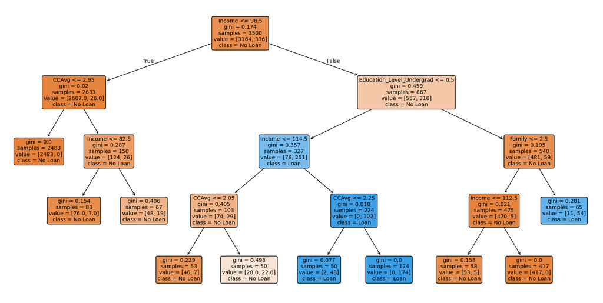

```python
# Visualize the Decision Tree
# Also find the Feature Importance
# --- Visualize the Decision Tree ---
plt.figure(figsize=(20,10))
tree.plot_tree(
    model1,
    feature_names=X_train.columns,
    class_names=['No Loan', 'Loan'],
    filled=True,
    rounded=True,
    fontsize=10
)
plt.show()
```

```python
feature_importance = pd.DataFrame({
    'Feature': X_train.columns,
    'Importance': model1.feature_importances_
}).sort_values(by='Importance', ascending=False).reset_index(drop=True)
important_features = feature_importance[feature_importance['Importance'] > 0]

print("=== Non-zero Feature Importances ===")
print(important_features.to_string(index=False))
```

```
=== Non-zero Feature Importances ===
                  Feature  Importance
                   Income    0.465408
Education_Level_Undergrad    0.353497
                   Family    0.154057
                    CCAvg    0.027039
```

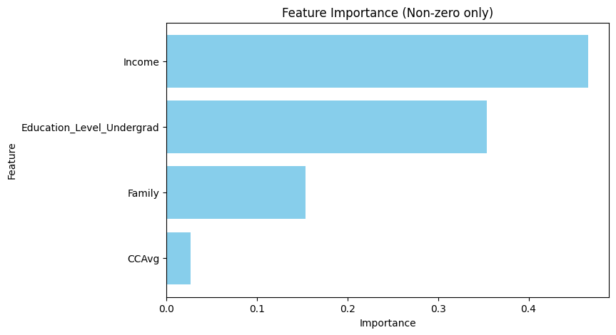

```python
important_features = feature_importance[feature_importance['Importance'] > 0]

# Plot bar chart
plt.figure(figsize=(8, 5))
plt.barh(important_features['Feature'], important_features['Importance'], color="skyblue")
plt.xlabel("Importance")
plt.ylabel("Feature")
plt.title("Feature Importance (Non-zero only)")
plt.gca().invert_yaxis()  # Highest importance on top
plt.show()
```